# Part II - Ford GoBike Dataset Explanation Analysis

## Investigation Overview

#### In this dataset Ford GoBike 2019:

- Exploration process completed successfully
- Includes Data wrangling, and some questions that answered by the visuals
- There Will be 3 questions

## Dataset Overview and Executive Summary

The dataset, 2019-fordgobike-tripdata.csv, is downloaded from Udacity and licensed by Ford GoBike. This dataset includes 183,412 trips with 16 features such as duration_sec (time of take the bike in seconds), start_time and end, and type of user and its gender, there are also id for the bike, stations, and finally wethear the bike shared durnig the trip or not .

#### summary of data wrangling process that performed:

```python
# import all packages and set plots to be embedded inline
import numpy as np
import pandas as pd
import matplotlib.pyplot as plt
import seaborn as sns
import matplotlib.ticker as mtick


# suppress warnings from final output
import warnings
warnings.simplefilter("ignore")
```

```python
# load in the dataset into a pandas dataframe
# Loading the data
df = pd.read_csv('201902-fordgobike-tripdata.csv')
# Display the first few rows
df.head()
```

|  | duration_sec | start_time | end_time | start_station_id | start_station_name | start_station_latitude | start_station_longitude | end_station_id | end_station_name | end_station_latitude | end_station_longitude | bike_id | user_type | member_birth_year | member_gender | bike_share_for_all_trip |
| --- | --- | --- | --- | --- | --- | --- | --- | --- | --- | --- | --- | --- | --- | --- | --- | --- |
| 0 | 52185 | 2019-02-28 17:32:10.1450 | 2019-03-01 08:01:55.9750 | 21.0 | Montgomery St BART Station (Market St at 2nd St) | 37.789625 | -122.400811 | 13.0 | Commercial St at Montgomery St | 37.794231 | -122.402923 | 4902 | Customer | 1984.0 | Male | No |
| 1 | 42521 | 2019-02-28 18:53:21.7890 | 2019-03-01 06:42:03.0560 | 23.0 | The Embarcadero at Steuart St | 37.791464 | -122.391034 | 81.0 | Berry St at 4th St | 37.775880 | -122.393170 | 2535 | Customer | NaN | NaN | No |
| 2 | 61854 | 2019-02-28 12:13:13.2180 | 2019-03-01 05:24:08.1460 | 86.0 | Market St at Dolores St | 37.769305 | -122.426826 | 3.0 | Powell St BART Station (Market St at 4th St) | 37.786375 | -122.404904 | 5905 | Customer | 1972.0 | Male | No |
| 3 | 36490 | 2019-02-28 17:54:26.0100 | 2019-03-01 04:02:36.8420 | 375.0 | Grove St at Masonic Ave | 37.774836 | -122.446546 | 70.0 | Central Ave at Fell St | 37.773311 | -122.444293 | 6638 | Subscriber | 1989.0 | Other | No |
| 4 | 1585 | 2019-02-28 23:54:18.5490 | 2019-03-01 00:20:44.0740 | 7.0 | Frank H Ogawa Plaza | 37.804562 | -122.271738 | 222.0 | 10th Ave at E 15th St | 37.792714 | -122.248780 | 4898 | Subscriber | 1974.0 | Male | Yes |

### Before visualizaion:

I will perform the steps of wrangling data first

```python
# Due to the size of dataset which is large comparing to the number of null values, I will remove them all
df.dropna(inplace= True) # inplace used here to perform the task immediatly
```

```python
# They seems string, lets covert them into datetime
df['start_time'] = pd.to_datetime(df['start_time'])
df['end_time'] = pd.to_datetime(df['end_time'])
```

```python
# Now its time to split the time's columns into two column, one for date and the other for time, will be applied for both start_time & end_time
df['date_start'] = df['start_time'].dt.date  # Extract date
df['time_start'] = df['start_time'].dt.strftime('%H:%M:%S.%f')  # Extract time including milliseconds
# Now the same process for end_time column
df['date_end'] = df['end_time'].dt.date
df['time_end'] = df['end_time'].dt.strftime('%H:%M:%S.%f')
```

```python
# As we see the new columns created, now its time to remove the old columns start_time, and end_time
df.drop(columns=['start_time'], inplace=True)
df.drop(columns=['end_time'], inplace=True)
# As I wrote above in the previous cells, the inplace argument used to perform the task immediately
```

```python
# Now you have noticed that the columns  start_station_longitude & end_station_longitude values all nagative
# There is no reason to make them nagative so lets convert them into postive!
df['start_station_longitude'] = df['start_station_longitude'].abs() # using abs() method will convert all - values into +
df['end_station_longitude'] = df['end_station_longitude'].abs()
```

## Bar Chart

### Top 10 station that has trips

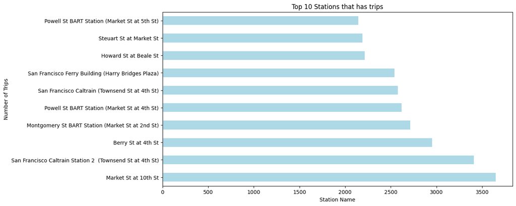

```python
# Now its time to draw the bar chat

# First lets count unique station names
unique_stations = df['start_station_name'].nunique()

# Lets get the number(count or frequency) of each station
station_counts = df['start_station_name'].value_counts()

# Now lets plot the most stations that use the bike from
plt.figure(figsize=(12, 6)) # as usual set the size of plot
station_counts.head(10).plot(kind='barh', color='lightblue') # here plotting the top 10 station
# the remains uaual steps
plt.xlabel('Station Name')
plt.ylabel('Number of Trips')
plt.title('Top 10 Stations that has trips')
plt.show()
```

#### Based on the visual above:

> The top 10 station that have trips is:
- Market St at 10th St
- San Francisco Caltrain Station 2 (Townsend St at 4th St)
- Berry St at 4th St
- Montgomery St BART Station (Market St at 2nd St)
- Powell St BART Station (Market St at 4th St)
- San Francisco Caltrain (Townsend St at 4th St)
- San Francisco Ferry Building (Harry Bridges Plaza)
- Howard St at Beale St
- Steuart St at Market St
- Powell St BART Station (Market St at 5th St)

## The Heat Map

### Usually, Which is the highest path for (start to take and submit) the bike?

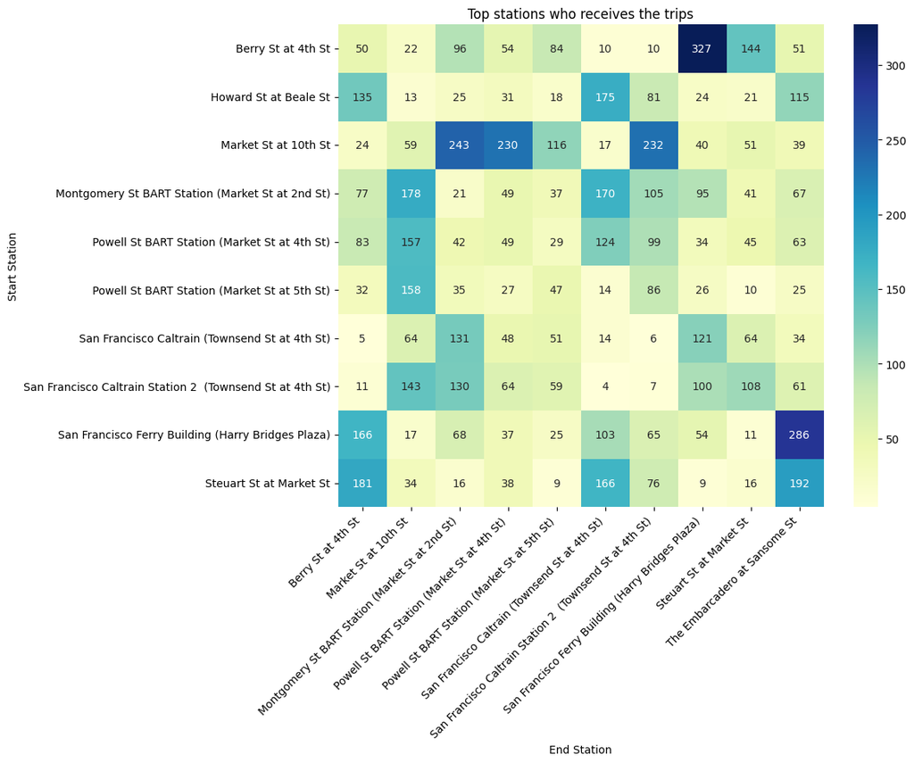

```python
# Step 1: Count trips for each station
top_n = 10  # Set the number of top stations to keep
top_start_stations = df['start_station_name'].value_counts().nlargest(top_n).index
top_end_stations = df['end_station_name'].value_counts().nlargest(top_n).index

# Step 2: Filter the df to only include top stations
filtered_df = df[df['start_station_name'].isin(top_start_stations) &
                  df['end_station_name'].isin(top_end_stations)]

# Step 3: Prepare the data - create a pivot table
heatmap_data = filtered_df.pivot_table(index='start_station_name',
                                        columns='end_station_name',
                                        values='duration_sec',  # You can use duration_sec
                                        aggfunc='count',  # Count the number of trips
                                        fill_value=0)  # Fill missing values with 0 if there any

# Step 4: Now let come to the desired point, creating the heat map!
plt.figure(figsize=(10, 8)) # Lets set the size to the best possible for looking the plot
sns.heatmap(heatmap_data, cmap='YlGnBu', annot=True, fmt='g')  # Set annot to true to see counts, cmap to YlGnBu to make the color good for looking
plt.title('Top stations who receives the trips')
plt.xlabel('End Station')
plt.ylabel('Start Station')
plt.xticks(rotation=45, ha='right')  # Rotate x-axis labels for better readability
plt.show()
```

#### The heat maps gave an informative findings, based on easily illestrated the question

> It turns out the highest people used the following path to start and finish their trip! starting from Berry St at 4th St, and submit their bike in San Francisco Ferry Building (Harry Bridges Plaza)

## Matrix chart

### How do user types (Customers vs Subscribers) differ in their trip duration, starting latitude, and starting longitude

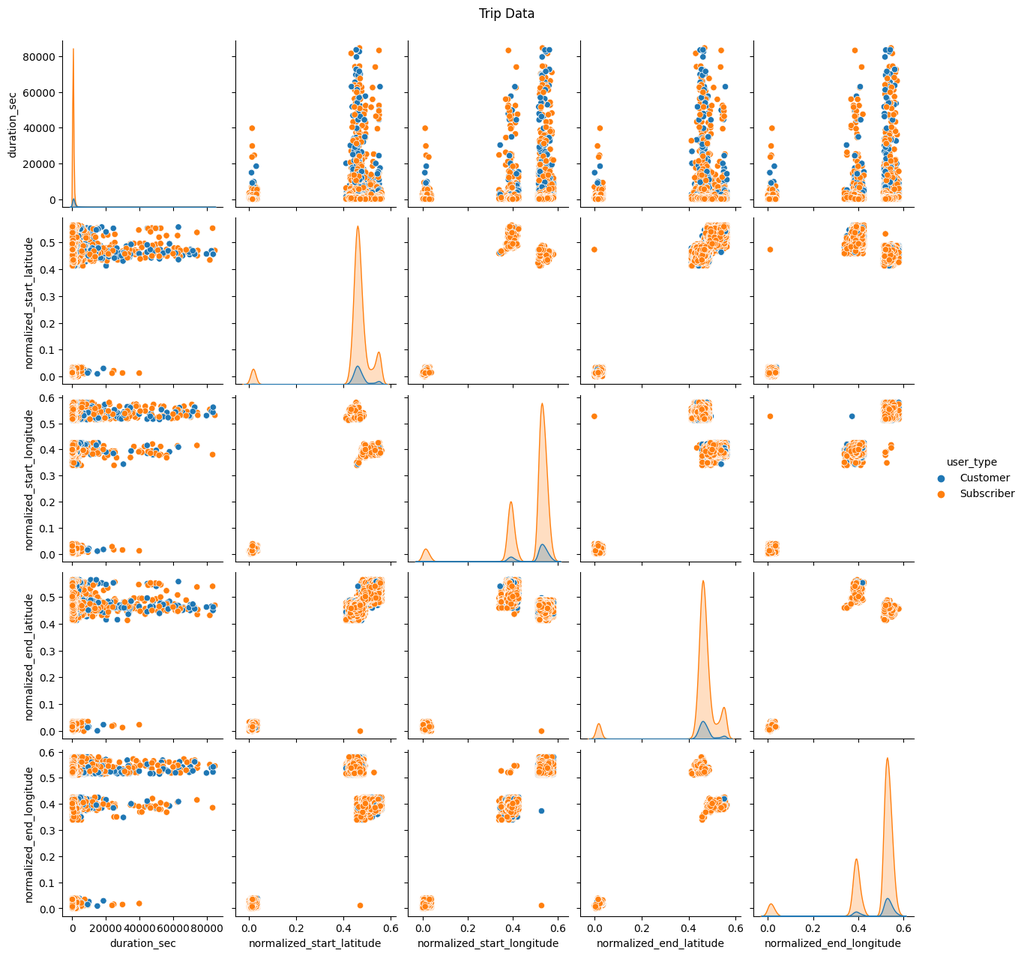

```python
# Normalize longitude and latitude to start from 0 and then will be relative frequency for better organizing
df['normalized_start_latitude'] = df['start_station_latitude'] - df['start_station_latitude'].min()
df['normalized_start_longitude'] = df['start_station_longitude'] - df['start_station_longitude'].min()
df['normalized_end_latitude'] = df['end_station_latitude'] - df['end_station_latitude'].min()
df['normalized_end_longitude'] = df['end_station_longitude'] - df['end_station_longitude'].min()

# Select relevant columns for the pairplot with normalized values as you see
numerical_cols_normalized = [
    'duration_sec',
    'normalized_start_latitude',
    'normalized_start_longitude',
    'normalized_end_latitude',
    'normalized_end_longitude'
]
# Create a pairplot with hue set to user_type (the legend will appear in the right)
# When they match two col like duration_sec vs duration_sec will repreasented as line chart, otherwise it will be scatter
sns.pairplot(df[numerical_cols_normalized + ['user_type']], hue='user_type')
plt.suptitle('Trip Data', y=1.02)
plt.show()
```